# Invasional meltdown: plant

Zhijie_Zhang

04 August, 2020

The codes for the paper **Soil-microbes-mediated invasional meltdown in plants**. This is the analyses for plant data.

**Tested questions:**

1. how soil species modifies competitive outcomes (i.e. biomass across alone, monoculture and bi-culture; section 2; Fig. 3a)
   - whether presence of soil species matters
   - whether home vs away matters (i.e. soil and test species are the same species)
   - whether origin of soil species matters (native vs alien)
   - whether origin of test species matters
2. how soil species modifies growth rate of test species (test plants that were grown alone; section 1; Fig. 3b; beta_alone)
3. how soil species modifies response to intra- or interspecific competition (section 2; Fig.3c; beta_inter and beta_intra)

```r
knitr::opts_chunk$set(warning=F,message = F)
```

```r
library(tidyverse)
library(nlme)
library(knitr)
library(RColorBrewer)
library(gridExtra)
dir.create("fig",   showWarnings = FALSE) # create folder for figures
dir.create('table', showWarnings = F)     # create folder for tables
```

read data

```r
load('plant.RData') # I saved all results, so I do not have to re-run the model.
source('01functions.R')
dat <- read.csv('03plant_dat.csv', stringsAsFactors = FALSE)
```

# 1 How soil species modifies growth rate of test species

(test plants that were grown alone)

**Four scenarios in soil phase:**

1. no soil species (empty pots in soil phase 2.1 soil and test species are the same species  
   2.2 they are different species  
   2.2.1 soil species is native  
   2.2.2 soil species is alien

data prep

```r
dat_lambda <- dat %>%
  filter(competition == "alone") %>%
  mutate(treat = ifelse(sp_p1 == "empty", "empty",
                        ifelse(sp_p1 == target, "own", origin_p1)))
```

## 1.1 Tables

### 1.1.1 aboveground

Here, I generate 3 contrasts:

- T1, 1 vs 2: whether presence of soil species matters
- T2, 2.1 vs 2.2: whether home vs away matters
- T3, 2.2.1 vs 2.2.2 when in away soil, whether origin matters (soil conditioned by natives vs soil conditioned by aliens)

see [https://stats.idre.ucla.edu/r/library/r-library-contrast-coding-systems-for-categorical-variables/] for details of how to generate contrasts in R.

```r
mat_lambda <- matrix(c(1/4, 1/4, 1/4,  1/4,
                      -1,   1/3, 1/3,  1/3, # T1
                       0,   1,  -1/2, -1/2, # T2
                       0,   0,   1,   -1  ),# T3
                      ncol=4)

mymat_lambda = solve(t(mat_lambda))

fun_round <- function(x) {
  ifelse (abs(x) < 0.00001, 0 , x)
} # the solve function will have round problem. Although this is not going to affect the results, I force small values to be 0.
contrast_lambda <- mymat_lambda[,2:4] %>%
  as.data.frame() %>%
  mutate_if(is.numeric, fun_round) %>%
  mutate(treat = c('empty', 'own', 'alien', 'native'))

names(contrast_lambda)[1:3] <- c('T1_empty', 'T2_home_away', 'T3_origin')

dat_lambda <- dat_lambda %>%
  left_join(contrast_lambda)
rm(mat_lambda, mymat_lambda, fun_round)
```

```r
u<-gl(1,1,length(dat_lambda$biomass))
```

```r
m_lambda <- lme(sqrt(biomass) ~ trans_date_c +
                  (T1_empty + T2_home_away + T3_origin) * origin_p2,
                random=list(u = pdBlocked(list(
                  pdIdent(form = ~ family-1),
                  pdIdent(form = ~ target-1),
                  pdIdent(form = ~ sp_p1-1),
                  pdIdent(form = ~ family_p1-1)
                  ))),
                weights=varComb(varIdent(form= ~1|target),
                                varIdent(form= ~1|sp_p1),
                                varIdent(form= ~1|treat)),
                control = lmeControl(msMaxIter = 1000),
                data=dat_lambda, method = "ML")
```

```r
table_ab <- drop1_single(m_lambda)
```

```r
table_ab %>% kable()
```

|  | X2 | P |
| --- | --- | --- |
| trans_date_c | 13.379 | 0.000* |
| T1_empty | 7.618 | 0.006* |
| T2_home_away | 0.176 | 0.675 |
| T3_origin | 0.180 | 0.672 |
| origin_p2 | 0.025 | 0.875 |
| T1_empty:origin_p2 | 0.076 | 0.783 |
| T2_home_away:origin_p2 | 0.021 | 0.884 |
| T3_origin:origin_p2 | 2.902 | 0.088† |
| Random effects | SD |  |
| family | 0.191 |  |
| target | 0.223 |  |
| sp_p1 | 0.055 |  |
| family_p1 | 0.056 |  |
| Residual | 0.293 |  |

### 1.1.2 total biomass

```r
dat_lambda_total <- dat_lambda %>%
  mutate(total = biomass + root) %>%
  filter(!is.na(total))

u <- gl(1, 1, length(dat_lambda_total$biomass))
```

```r
m_lambda    <-  update(m_lambda,sqrt(total) ~., data=dat_lambda_total)
table_total <- drop1_single(m_lambda)
```

```r
table_total %>% kable()
```

|  | X2 | P |
| --- | --- | --- |
| trans_date_c | 13.265 | 0.000* |
| T1_empty | 8.430 | 0.004* |
| T2_home_away | 1.834 | 0.176 |
| T3_origin | 0.189 | 0.663 |
| origin_p2 | 0.229 | 0.632 |
| T1_empty:origin_p2 | 1.263 | 0.261 |
| T2_home_away:origin_p2 | 0.130 | 0.718 |
| T3_origin:origin_p2 | 4.563 | 0.033* |
| Random effects | SD |  |
| family | 0.314 |  |
| target | 0.193 |  |
| sp_p1 | 0.060 |  |
| family_p1 | 0.053 |  |
| Residual | 0.327 |  |

### 1.1.3 belowground

```r
dat_lambda_root <- dat_lambda %>%
  filter(!is.na(root))
u<-gl(1,1,length(dat_lambda_root$root))
```

```r
m_lambda    <- update(m_lambda, sqrt(root)~., data=dat_lambda_root)
table_below <- drop1_single(m_lambda)
```

```r
table_below %>% kable()
```

|  | X2 | P |
| --- | --- | --- |
| trans_date_c | 7.596 | 0.006* |
| T1_empty | 11.756 | 0.001* |
| T2_home_away | 2.929 | 0.087† |
| T3_origin | 0.874 | 0.350 |
| origin_p2 | 1.995 | 0.158 |
| T1_empty:origin_p2 | 5.439 | 0.020* |
| T2_home_away:origin_p2 | 0.150 | 0.699 |
| T3_origin:origin_p2 | 3.232 | 0.072† |
| Random effects | SD |  |
| family | 0.240 |  |
| target | 0.098 |  |
| sp_p1 | 0.019 |  |
| family_p1 | 0.000 |  |
| Residual | 0.251 |  |

export tables

```r
# write.csv(cbind(table_ab, table_below, table_total), './table/alone.csv')
```

## 1.2 Figures

**Major findings**:

1. test species decreased their biomass in presence of soil species.
2. test species increased their biomass in soil conditioned by aliens, in contrast to soil conditioned by natives (disappeared after adding phase-1 biomass).
3. Compared with native test species, alien test species increased their biomass in soil conditioned by aliens. But in soil conditioned by natives, this pattern was not apparent.

plot function

```r
theme <-theme(panel.background = element_blank(),
              panel.border     = element_rect(fill = NA),
              strip.background = element_blank(),
              axis.text.x = element_text(size = 5.5, angle = 0, hjust = 0.5, colour = 'black'),
              axis.text.y  = element_text(size = 6, colour = 'black'),
              axis.title = element_text(size = 6),# size of y lab
              legend.position   = c(0.9, 0.85),
              legend.title      = element_text(size = 6),
              legend.text       = element_text(size = 6),
              legend.key.height = unit(0.7,'line'),
              legend.background = element_blank(),
              legend.key        = element_rect(colour = NA, fill = NA),
              plot.tag    = element_text(size = 7, face  = 'bold'),
              plot.title  = element_text(hjust = 0.5, size = 7),
              plot.margin = margin(t = 0.5, r = 0.1, b = 0, l = 0.1, unit = "cm"))
```

```r
col_fig <- c('#FFA733', '#971997')
```

### 1.2.1 aboveground biomass (Fig. 3b)

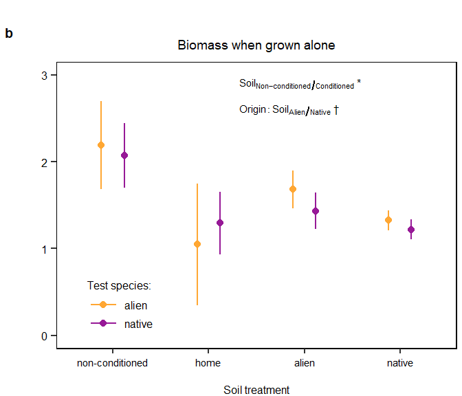

```r
p_alone <- plot_alone(legend = F, tag = 'b', xlab = '\nSoil treatment') + theme(legend.position = c(0.16,0.15)) +
  annotate("text", x = 4.8, y = 2.9, label = expression(Soil[Non-conditioned/Conditioned] ~ '*'), hjust = 0, size = 2) +
  annotate("text", x = 4.8, y = 2.6, label = expression(Origin : Soil[Alien/Native] ~ '\u2020'),  hjust = 0, size = 2) +
  labs(x = '\nSoil treatment', y = ' \n', title = 'Biomass when grown alone')
p_alone
```

### 1.2.2 belowground and total biomass (Extended Fig.1)

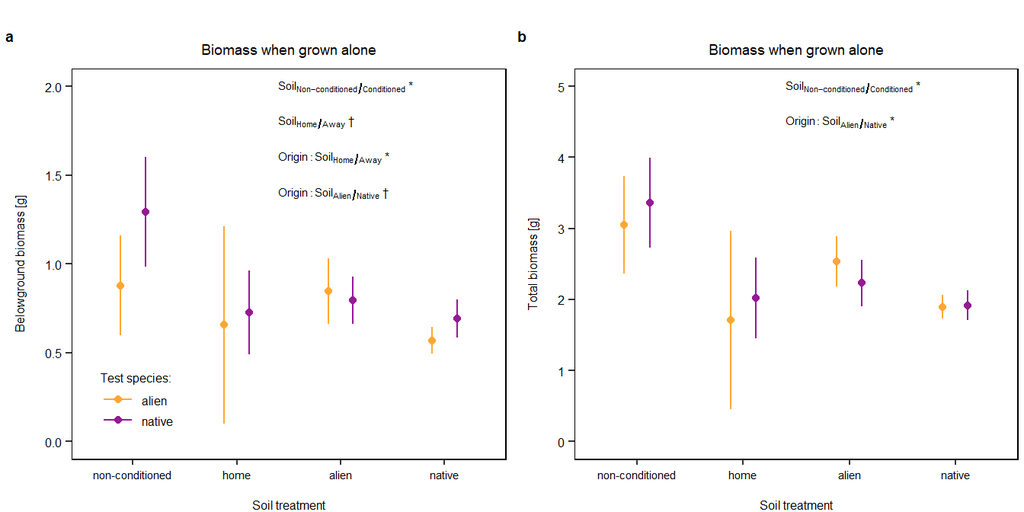

```r
#below
p1 <- plot_alone(dat_lambda_root, variable = 'root',
                 ylab = 'Belowground biomass [g]\n', ylim = c(0,2),
                 tag = 'a') +
  theme(legend.position = c(0.15,0.15)) +
  annotate("text", x = 5, y = 2, label = expression(Soil[Non-conditioned/Conditioned] ~ '*'), hjust = 0, size = 2) +
  annotate("text", x = 5, y = 1.8, label = expression(Soil[Home/Away] ~ '\u2020'), hjust = 0, size = 2) +
  annotate("text", x = 5, y = 1.6, label = expression(Origin : Soil[Home/Away] ~ '*'), hjust = 0, size = 2) +
  annotate("text", x = 5, y = 1.4, label = expression(Origin : Soil[Alien/Native] ~ '\u2020'), hjust = 0, size = 2)

# total
p2 <- plot_alone(dat_lambda_total, variable = 'total',
                 ylab = 'Total biomass [g]\n', ylim = c(0,5),
                 tag = 'b', legend = F) +
  annotate("text", x = 5, y = 5, label = expression(Soil[Non-conditioned/Conditioned] ~ '*'), hjust = 0, size = 2) +
  annotate("text", x = 5, y = 4.5, label = expression(Origin : Soil[Alien/Native] ~ '*'), hjust = 0, size = 2)


grid.arrange(p1,p2, ncol =2, nrow = 1)
```

```r
ggsave('./fig/sup_alone.pdf', grid.arrange(p1, p2, ncol =2, nrow = 1), height = 2.7, width = 14/2.54, useDingbats=FALSE)
```

# 2 How soil species modify plants, all data together

(Aboveground biomass was used, as it is almost impossible to seperate roots of plants that were grown together)

```r
dat_all <- dat %>%
  mutate(treat = ifelse(sp_p1 == "empty", "empty", # 1 or 2
                        ifelse(sp_p1 == target, "own", origin_p1))) %>%
  #---------------- contrasts for soil treatments ---------------------#
  left_join(contrast_lambda) %>%
  #------------- contrasts for competition treatments -----------------#
  mutate(t1_alone_comp  =  ifelse(competition=="alone", -2/3, 1/3)) %>% # contrast for alone vs competition
  mutate(t2_intra_inter =  ifelse(competition=="alone",  0,
                                  ifelse(competition=="intra", 0.5, -0.5)))
```

## 2.1 Tables

### 2.1.1 main analyses (Table 1)

```r
u <- gl(1,1,length(dat_all$biomass))
```

```r
m_all <- lme(sqrt(biomass) ~ trans_date_c +
               (T1_empty + T2_home_away + T3_origin) * origin_p2 * (t1_alone_comp + t2_intra_inter),
             random = list(u = pdBlocked(list(
               pdIdent(form = ~ family-1),
               pdIdent(form = ~ target-1), # focal test species
               pdIdent(form = ~ family_comp-1),
               pdIdent(form = ~ comp-1),  # competitor
               pdIdent(form = ~ sp_p1-1), # soil species
               pdIdent(form = ~ family_p1-1)
               ))),
             weights = varComb(varIdent(form=~1|target),
                               varIdent(form=~1|sp_p1),
                               varIdent(form=~1|treat)
                               ),
             control = lmeControl(maxIter = 50000, msMaxIter = 50000, msMaxEval = 50000),
             data = dat_all, method="ML")
```

```r
m_all_r2  <- update(m_all,    .~.-(T1_empty+T2_home_away+T3_origin):origin_p2:(t1_alone_comp+t2_intra_inter))
m_all_r3  <- update(m_all_r2, .~ trans_date_c+(T1_empty+T2_home_away+T3_origin)+origin_p2+(t1_alone_comp+t2_intra_inter))

all_r1 <- drop1(m_all,    test="Chisq")[-c(1,2),]
all_r2 <- drop1(m_all_r2, test="Chisq")[-c(1,2),]
all_r3 <- drop1(m_all_r3, test="Chisq")[-c(1,2),]
all_r4 <- drop1(update(m_all_r3, .~trans_date_c),test="Chisq")[-1,]
```

```r
lrt.table(rbind(all_r4,all_r3,all_r2,all_r1))
```

|  | Df | AIC | LRT | Pr(>Chi) |  |
| --- | --- | --- | --- | --- | --- |
| trans_date_c | 1 | -48.745 | 12.815 | 0.000 | * |
| T1_empty | 1 | -58.565 | 10.306 | 0.001 | * |
| T2_home_away | 1 | -64.335 | 4.535 | 0.033 | * |
| T3_origin | 1 | -68.763 | 0.107 | 0.744 |  |
| origin_p2 | 1 | -68.788 | 0.083 | 0.774 |  |
| t1_alone_comp | 1 | -65.132 | 3.738 | 0.053 | † |
| t2_intra_inter | 1 | -68.075 | 0.795 | 0.373 |  |
| T1_empty:origin_p2 | 1 | -63.289 | 1.395 | 0.238 |  |
| T2_home_away:origin_p2 | 1 | -63.015 | 1.669 | 0.196 |  |
| T3_origin:origin_p2 | 1 | -59.943 | 4.741 | 0.029 | * |
| T1_empty:t1_alone_comp | 1 | -63.728 | 0.956 | 0.328 |  |
| T1_empty:t2_intra_inter | 1 | -64.508 | 0.176 | 0.675 |  |
| T2_home_away:t1_alone_comp | 1 | -64.563 | 0.121 | 0.728 |  |
| T2_home_away:t2_intra_inter | 1 | -62.411 | 2.273 | 0.132 |  |
| T3_origin:t1_alone_comp | 1 | -59.838 | 4.846 | 0.028 | * |
| T3_origin:t2_intra_inter | 1 | -64.363 | 0.321 | 0.571 |  |
| origin_p2:t1_alone_comp | 1 | -64.435 | 0.249 | 0.618 |  |
| origin_p2:t2_intra_inter | 1 | -64.313 | 0.371 | 0.542 |  |
| T1_empty:origin_p2:t1_alone_comp | 1 | -56.216 | 0.511 | 0.475 |  |
| T1_empty:origin_p2:t2_intra_inter | 1 | -56.726 | 0.001 | 0.972 |  |
| T2_home_away:origin_p2:t1_alone_comp | 1 | -55.002 | 1.725 | 0.189 |  |
| T2_home_away:origin_p2:t2_intra_inter | 1 | -56.571 | 0.156 | 0.693 |  |
| T3_origin:origin_p2:t1_alone_comp | 1 | -56.530 | 0.197 | 0.657 |  |
| T3_origin:origin_p2:t2_intra_inter | 1 | -56.727 | 0.000 | 0.990 |  |

```r
# write.csv(merge_fix_rand(rbind(all_r4,all_r3,all_r2,all_r1), m_all), './table/t_all.csv')
```

### 2.1.2 without soil spp = test comp species

Supplementary Table 2

```r
dat_all2 <- dat_all %>%
  filter(!(competition == 'inter' & sp_p1 == comp))
u <- gl(1,1,length(dat_all2$biomass))
```

```r
m_all2 <- update(m_all, data = dat_all2)
m_all2_r2 <- update(m_all2,    .~. -(T1_empty+T2_home_away+T3_origin):origin_p2:(t1_alone_comp+t2_intra_inter))
m_all2_r3 <- update(m_all2_r2, .~ trans_date_c+(T1_empty+T2_home_away+T3_origin)+origin_p2+(t1_alone_comp+t2_intra_inter))

all2_r1 <- drop1(m_all2,    test="Chisq")[-c(1,2),]
all2_r2 <- drop1(m_all2_r2, test="Chisq")[-c(1,2),]
all2_r3 <- drop1(m_all2_r3, test="Chisq")[-c(1,2),]
all2_r4 <- drop1(update(m_all2_r3,. ~ trans_date_c), test="Chisq")[-1,]
```

```r
lrt.table(rbind(all2_r4,all2_r3,all2_r2,all2_r1))
```

|  | Df | AIC | LRT | Pr(>Chi) |  |
| --- | --- | --- | --- | --- | --- |
| trans_date_c | 1 | -50.750 | 12.693 | 0.000 | * |
| T1_empty | 1 | -59.717 | 10.624 | 0.001 | * |
| T2_home_away | 1 | -66.263 | 4.079 | 0.043 | * |
| T3_origin | 1 | -70.262 | 0.080 | 0.778 |  |
| origin_p2 | 1 | -70.256 | 0.086 | 0.770 |  |
| t1_alone_comp | 1 | -66.660 | 3.681 | 0.055 | † |
| t2_intra_inter | 1 | -69.863 | 0.479 | 0.489 |  |
| T1_empty:origin_p2 | 1 | -67.024 | 1.204 | 0.273 |  |
| T2_home_away:origin_p2 | 1 | -66.249 | 1.979 | 0.160 |  |
| T3_origin:origin_p2 | 1 | -61.890 | 6.338 | 0.012 | * |
| T1_empty:t1_alone_comp | 1 | -67.321 | 0.906 | 0.341 |  |
| T1_empty:t2_intra_inter | 1 | -67.972 | 0.256 | 0.613 |  |
| T2_home_away:t1_alone_comp | 1 | -68.121 | 0.107 | 0.744 |  |
| T2_home_away:t2_intra_inter | 1 | -66.225 | 2.003 | 0.157 |  |
| T3_origin:t1_alone_comp | 1 | -62.731 | 5.497 | 0.019 | * |
| T3_origin:t2_intra_inter | 1 | -68.101 | 0.127 | 0.721 |  |
| origin_p2:t1_alone_comp | 1 | -67.953 | 0.275 | 0.600 |  |
| origin_p2:t2_intra_inter | 1 | -67.833 | 0.395 | 0.529 |  |
| T1_empty:origin_p2:t1_alone_comp | 1 | -59.778 | 0.447 | 0.504 |  |
| T1_empty:origin_p2:t2_intra_inter | 1 | -60.224 | 0.001 | 0.979 |  |
| T2_home_away:origin_p2:t1_alone_comp | 1 | -58.473 | 1.751 | 0.186 |  |
| T2_home_away:origin_p2:t2_intra_inter | 1 | -59.964 | 0.260 | 0.610 |  |
| T3_origin:origin_p2:t1_alone_comp | 1 | -60.146 | 0.079 | 0.779 |  |
| T3_origin:origin_p2:t2_intra_inter | 1 | -60.145 | 0.080 | 0.777 |  |

```r
# write.csv(merge_fix_rand(rbind(all2_r4,all2_r3,all2_r2,all2_r1), m_all2), './table/t_all_no_pair.csv')
```

### 2.1.3 with biomass of soil plants as covariate

Supplementary Table 3

```r
u <- gl(1,1,length(dat_all$biomass))
```

```r
m_all_co    <-  update(m_all,      .~. + scale(sqrt(bio_p1_0)))
m_all_co_r2 <-  update(m_all_co,   .~.-(T1_empty+T2_home_away+T3_origin):origin_p2:(t1_alone_comp+t2_intra_inter))#2 way
m_all_co_r3 <-  update(m_all_co_r2,.~ scale(sqrt(bio_p1_0)) + trans_date_c +
                         (T1_empty + T2_home_away + T3_origin) + origin_p2 + (t1_alone_comp + t2_intra_inter))#main
m_all_co_r4 <-  update(m_all_co_r2,.~ scale(sqrt(bio_p1_0))+trans_date_c)


all_co_r1   <-  drop1(m_all_co,    test="Chisq")[-c(1,2,3),]
all_co_r2   <-  drop1(m_all_co_r2, test="Chisq")[-c(1,2,3),]
all_co_r3   <-  drop1(m_all_co_r3, test="Chisq")[-c(1,2,3),]
all_co_r4   <-  drop1(m_all_co_r4,test="Chisq")[-1,]
```

```r
lrt.table(rbind(all_co_r4,all_co_r3,all_co_r2,all_co_r1))
```

|  | Df | AIC | LRT | Pr(>Chi) |  |
| --- | --- | --- | --- | --- | --- |
| scale(sqrt(bio_p1_0)) | 1 | -59.560 | 46.489 | 0.000 | * |
| trans_date_c | 1 | -105.132 | 0.917 | 0.338 |  |
| T1_empty | 1 | -103.296 | 4.758 | 0.029 | * |
| T2_home_away | 1 | -103.427 | 4.627 | 0.031 | * |
| T3_origin | 1 | -107.952 | 0.102 | 0.749 |  |
| origin_p2 | 1 | -107.977 | 0.077 | 0.781 |  |
| t1_alone_comp | 1 | -104.332 | 3.722 | 0.054 | † |
| t2_intra_inter | 1 | -107.106 | 0.948 | 0.330 |  |
| T1_empty:origin_p2 | 1 | -103.151 | 1.720 | 0.190 |  |
| T2_home_away:origin_p2 | 1 | -102.091 | 2.781 | 0.095 | † |
| T3_origin:origin_p2 | 1 | -100.953 | 3.918 | 0.048 | * |
| T1_empty:t1_alone_comp | 1 | -104.191 | 0.680 | 0.409 |  |
| T1_empty:t2_intra_inter | 1 | -104.773 | 0.098 | 0.754 |  |
| T2_home_away:t1_alone_comp | 1 | -104.624 | 0.248 | 0.619 |  |
| T2_home_away:t2_intra_inter | 1 | -103.321 | 1.551 | 0.213 |  |
| T3_origin:t1_alone_comp | 1 | -98.685 | 6.187 | 0.013 | * |
| T3_origin:t2_intra_inter | 1 | -104.283 | 0.588 | 0.443 |  |
| origin_p2:t1_alone_comp | 1 | -104.518 | 0.353 | 0.552 |  |
| origin_p2:t2_intra_inter | 1 | -104.474 | 0.397 | 0.528 |  |
| T1_empty:origin_p2:t1_alone_comp | 1 | -96.314 | 0.485 | 0.486 |  |
| T1_empty:origin_p2:t2_intra_inter | 1 | -96.796 | 0.003 | 0.956 |  |
| T2_home_away:origin_p2:t1_alone_comp | 1 | -95.062 | 1.737 | 0.188 |  |
| T2_home_away:origin_p2:t2_intra_inter | 1 | -96.692 | 0.107 | 0.744 |  |
| T3_origin:origin_p2:t1_alone_comp | 1 | -96.675 | 0.124 | 0.725 |  |
| T3_origin:origin_p2:t2_intra_inter | 1 | -96.737 | 0.062 | 0.803 |  |

```r
# write.csv(merge_fix_rand(rbind(all_co_r4,all_co_r3,all_co_r2,all_co_r1), m_all_co), './table/t_all_co.csv')
```

## 2.2 Figures

### 2.2.1 across competition (competitive outcomes; Fig. 3a)

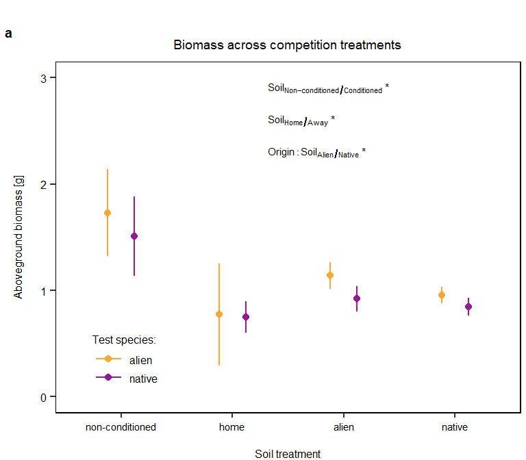

```r
p1 <- plot_alone(data = dat_all, title = 'Biomass across competition treatments', xlab = '\nSoil treatment') +
  theme(legend.position = c(0.15,0.15)) +
  annotate("text", x = 4.8, y = 2.9, label = expression(Soil[Non-conditioned/Conditioned] ~ '*'), hjust = 0, size = 2) +
  annotate("text", x = 4.8, y = 2.6, label = expression(Soil[Home/Away] ~ '*'),  hjust = 0, size = 2) +
  annotate("text", x = 4.8, y = 2.3, label = expression(Origin : Soil[Alien/Native] ~ '*'), hjust = 0, size = 2)
p1
```

### 2.2.2 responses to competition (Fig. 3c)

```r
at=c(1,2,     # empty
     3.5, 4.5,# own,i.e. same species
     6,   7,  # alien soil species
     8.5, 9.5 # native soil species
     )
t_lambda <- dat_lambda %>%
  group_by(target, sp_p1, treat, origin_p2) %>%
  summarise(mean_bio = mean(biomass)) %>%
  group_by(treat, origin_p2) %>%
  summarise(mean = mean(mean_bio),se = sd(mean_bio)/sqrt(n())) %>%
  arrange(match(treat, c("empty","own","alien","native"))) %>%
  mutate(comp = 'alone')
t_comp <- dat_all%>%
  filter(competition != "alone") %>%
  group_by(fix, target, sp_p1, treat, origin_p2, comb) %>%
  summarise(mean_bio = mean(biomass))%>%
  group_by(target, sp_p1, treat, origin_p2)%>%
  summarise(mean_bio = mean(mean_bio))%>%
  group_by(treat, origin_p2)%>%
  summarise(mean = mean(mean_bio),se = sd(mean_bio)/sqrt(n()))%>%
  arrange(match(treat, c("empty","own","alien","native"))) %>%
  mutate(comp = 'comp')

t_lambda_comp <- rbind(t_lambda,t_comp)
```

```r
at=c(1,1.2,  # empty
     3.5,3.7,# own,i.e. same species
     6,6.2,  # alien soil species
     8.5,8.7
     )
t_slope <- cbind(t_lambda[,-5], t_comp[,-5])


p3 <- t_lambda_comp %>%
  mutate(comp = ifelse(comp == 'alone', 'No', 'Yes')) %>%
  ggplot() +
  aes(x = c(at, at + 1), y = mean, col = origin_p2) +
  geom_errorbar(aes(ymin = mean - se, ymax = mean + se), width = 0, col = rep(col_fig, 8)) +
  scale_x_continuous(limits = c(0.5, 10), breaks = c(1.5,4,6.5,9), labels = c("non-conditioned","home","alien","native")) +
  scale_y_continuous(limits = c(0,3)) +
  scale_color_manual(values = col_fig) +
  scale_shape_manual(values = c(19, 21)) +
  labs(x = '\nSoil treatment', y = ' \n', title = 'Changes in biomass to competition', shape = 'Competition:', tag = 'c') +
  guides(col = F) +
  theme +
  geom_segment(aes(x = at, xend = at + 1, y = mean, yend = mean1), data = t_slope) +
  geom_point(aes(shape = comp), fill = 'white') +
  theme(legend.position = c(0.16,0.15)) +
  annotate("text", x = 4.4, y = 2.9, label = expression(Comp[Yes/No] ~ '\u2020'), hjust = 0, size = 2) +
  annotate("text", x = 4.4, y = 2.6, label = expression(Soil[Alien/Native] : Comp[Yes/No] ~ '*'), hjust = 0, size = 2)
```

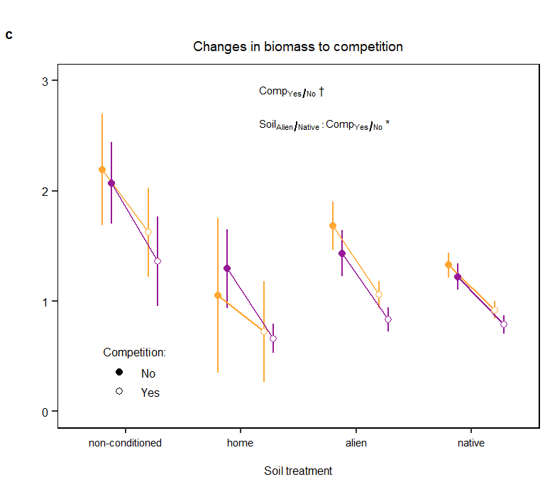

```r
p3
```

```r
ggsave('./fig/plant_main.pdf', grid.arrange(p1, p_alone, p3, nrow = 1),
       width = 18.8/2.54, height = 2.5, useDingbats=FALSE)
```

### 2.2.3 test-plant biomass ~ soil-plant biomass

Supplementary Fig. 2

```r
m_bio <- update(m_all_co_r4, .~ sqrt(bio_p1_0), method = 'REML')
```

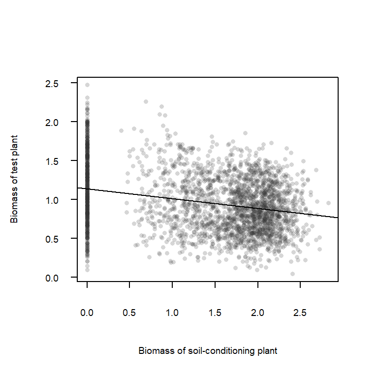

```r
# pdf('./fig/test_soil_biomass.pdf', width = 8/2.54, height = 8/2.54)
plot(sqrt(dat_all$bio_p1_0), sqrt(dat_all$biomass),ylab="Biomass of test plant",
     xlab = "Biomass of soil-conditioning plant",
     cex = 0.6, cex.axis = 0.6, cex.lab= 0.6, tck=-0.03,
     yaxt="n",col = rgb(red = .2, green = .2, blue = .2, alpha = 0.2),
     pch = 16)
axis(2,at=seq(0,2.5,0.5), labels=seq(0,2.5,0.5) %>% sprintf(fmt = '%#.1f'),las=1, cex.axis = 0.6, tck=-0.03)
abline(m_bio$coefficients$fixed[1],m_bio$coefficients$fixed[2])
```

```r
# dev.off()
```

# 3 export soil-legacy effects

These data is used to test relationship between soil-legacy effects and soil community similarity or diversity(or abundance) of soil pathogens.

## 3.1 beta_alone

Here, soil-legacy effects were based on test plants that were grown alone.

```r
dat_lambda_mean <- dat_lambda %>%
  group_by(sp_p1, family_p1, origin_p1, target, family, origin_p2) %>%
  dplyr::summarise(biomass = mean((biomass), na.rm = T))
dat_legacy_alone <- dat_lambda_mean%>%
  filter(sp_p1 != 'empty') %>%
  # get the ck: growth on no plant soil; and left join
  left_join(dat_lambda_mean %>%
              filter(sp_p1 == 'empty') %>% # use empty as control
              ungroup() %>%
              dplyr::select(target, biomass)%>%
              distinct() %>%
              dplyr::rename(biomass_ck = biomass), by = 'target')%>%
  mutate(legacy_alone = log(biomass/biomass_ck)) %>%  # log scale
  ungroup() %>%
  mutate(sp_p1 = sub(' ', '_', sp_p1),
         target = sub(' ','_', target)) %>%
  rename(sp_p2 = target)
```

## 3.2 beta_inter and beta_intra

Here, soil-legacy effects were the effect of soil species on strength of competition

```r
dat_mean <- dat_all %>%
  group_by(sp_p1, target, comp, family_p1, family, family_comp, origin_p2) %>%
  dplyr::summarise(biomass = mean(biomass))

# calculate strength of competition for each target x comp x soil combi
dat_mean <- dat_mean %>%
  filter(comp != 'alone') %>%
  left_join(dat_mean %>% filter(comp == 'alone') %>% ungroup %>%
              select(sp_p1, target, biomass) %>% rename(bio_alone = biomass)
              ) %>%
  mutate(stren_comp = log(biomass/bio_alone))

# calculate the changes in strength of competition by soil
dat_legacy_stren <- dat_mean %>%
  filter(sp_p1 != 'empty') %>%
  left_join(dat_mean %>% filter(sp_p1 == 'empty') %>% ungroup %>%
              select(target, comp, stren_comp) %>% rename(stren_comp_ck = stren_comp)) %>%
  mutate(legacy_stren = stren_comp - stren_comp_ck) %>%
  ungroup() %>%
  mutate(sp_p1  = sub(' ', '_', sp_p1),
         target = sub(' ', '_', target),
         comp   = sub(' ', '_', comp)) %>%
  rename(sp_p2      = target,
         sp_p2_comp = comp)
```

export the soil-legacy effect for soil analyses

```r
save(dat_legacy_alone, dat_legacy_stren, file = 'legacy_beta.RData')
```